# pset_1

Sabrina Zhang

2026-04-28

### [1]

I’m going to load the `pacman` package and then will use it to load the `tidyverse`, `scales`, `fixest`, `patchworks` and `here` packages. Then, I’ll read in the data from the `data-ps1.csv` file using the `read_csv()` function from the `readr` package, which is part of the `tidyverse`. The data will be stored in a data frame called `life_df`.

```r
library(pacman)
p_load(tidyverse, scales, fixest, here, patchwork)
life_df = here("~/Desktop/School Stuff/EC 421/pset_1/data-ps1.csv")|> read_csv()
```

### [2]

Number of Observations: 3106

Number of variables: 18

Number of Complete Observations: 3106

Number of Distinct Counties: 1051

Number of Distinct States: 50

Number of Observations in Q1: 1553

Number of Observations in Q4: 1553

```r
ncol(life_df)
```

```
## [1] 18
```

```r
nrow(life_df)
```

```
## [1] 3106
```

```r
life_df = na.omit(life_df)
ncol(life_df)
```

```
## [1] 18
```

```r
nrow(life_df)
```

```
## [1] 3106
```

```r
n_distinct(life_df$county_name)
```

```
## [1] 1051
```

```r
n_distinct(life_df$state_abb)
```

```
## [1] 50
```

```r
nrow(filter(life_df, income_quartile == 1))
```

```
## [1] 1553
```

```r
nrow(filter(life_df, income_quartile == 4))
```

```
## [1] 1553
```

### [3]

```r
life_df = mutate(life_df, high_income = as.numeric(income_quartile == 4))
life_df
```

```
## # A tibble: 3,106 × 19
##    county_name county_code state_abb income_quartile life_exp pct_uninsured
##    <chr>             <dbl> <chr>               <dbl>    <dbl>         <dbl>
##  1 Autauga            1001 AL                      1     76.4         0.136
##  2 Autauga            1001 AL                      4     84.2         0.136
##  3 Baldwin            1003 AL                      1     79.5         0.191
##  4 Baldwin            1003 AL                      4     86.3         0.191
##  5 Barbour            1005 AL                      1     79.7         0.185
##  6 Barbour            1005 AL                      4     86.7         0.185
##  7 Blount             1009 AL                      1     78.6         0.193
##  8 Blount             1009 AL                      4     86.3         0.193
##  9 Calhoun            1015 AL                      1     76.5         0.161
## 10 Calhoun            1015 AL                      4     84.9         0.161
## # ℹ 3,096 more rows
## # ℹ 13 more variables: poverty_rate <dbl>, pct_religious <dbl>,
## #   pct_black <dbl>, pct_hispanic <dbl>, unemployment_rate <dbl>,
## #   median_hh_inc <dbl>, is_urban <dbl>, pop <dbl>, pop_density <dbl>,
## #   pct_smoke <dbl>, pct_obese <dbl>, pct_exercise <dbl>, high_income <dbl>
```

### [4]

Generally we see that life expectancy is higher in Q4 income, the population in Q1 has higher rates of smoking and obesity, and does not exercise as much as the population in Q4.

```r
filtered_q1 = filter(life_df, high_income == 0)
filtered_q4 = filter(life_df, high_income == 1)

summary =
  tibble(
  id = c("life_exp", "pct_smoke", "pct_obese", "pct_exercise"),

  std_Q1 = c(sd(filtered_q1$life_exp), sd(filtered_q1$pct_smoke) * 100, sd(filtered_q1$pct_obese)*100,    sd(filtered_q1$pct_exercise)*100),
   std_Q4 = c(sd(filtered_q4$life_exp), sd(filtered_q4$pct_smoke) * 100, sd(filtered_q4$pct_obese)*100,    sd(filtered_q4$pct_exercise)*100),


  mean_Q1 = c(mean(filtered_q1$life_exp), mean(filtered_q1$pct_smoke)*100, mean(filtered_q1$pct_obese)*100, mean(filtered_q1$pct_exercise)*100),


  mean_Q4 = c(mean(filtered_q4$life_exp), mean(filtered_q4$pct_smoke)*100, mean(filtered_q4$pct_obese)*100, mean(filtered_q4$pct_exercise)*100)
)

summary
```

```
## # A tibble: 4 × 5
##   id           std_Q1 std_Q4 mean_Q1 mean_Q4
##   <chr>         <dbl>  <dbl>   <dbl>   <dbl>
## 1 life_exp       1.45   1.37    78.9    86.0
## 2 pct_smoke      7.96   7.91    28.1    13.0
## 3 pct_obese      8.91   9.79    30.8    23.3
## 4 pct_exercise   9.43   8.85    59.7    85.1
```

### [5]

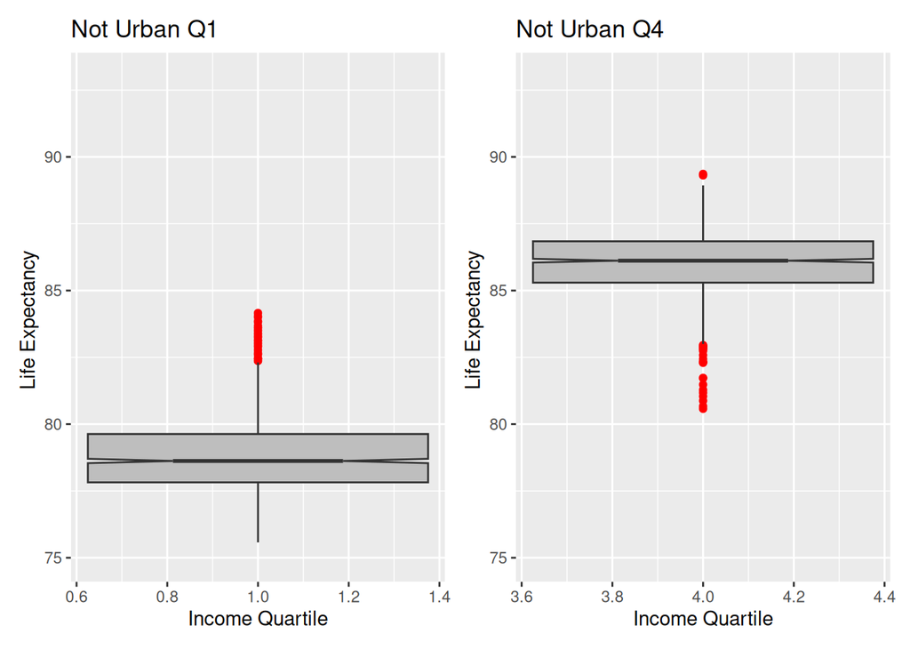

```r
create_boxplot = function(df, x, y, title, x_axis, y_axis)  {
  ggplot(data = df,
                 aes(x = {{x}}, y = {{y}}))+
  geom_boxplot(fill = "grey", notch = TRUE, outlier.colour = "red")+
    labs(title = title, x = x_axis, y = y_axis) + ylim(75,93)}

is_urbanQ1 = filter(life_df, is_urban == 0, high_income == 0)
is_urbanQ4 = filter(life_df, is_urban == 0, high_income == 1)

not_urbanQ1 = filter(life_df, is_urban == 1, high_income == 0)
not_urbanQ4 = filter(life_df, is_urban == 1, high_income == 1)

not_urban1 = create_boxplot(not_urbanQ1, income_quartile, life_exp,"Not Urban Q1", "Income Quartile", "Life Expectancy ")

not_urban4 = create_boxplot(not_urbanQ4, income_quartile, life_exp,"Not Urban Q4", "Income Quartile", "Life Expectancy ")

is_urban1 = create_boxplot(is_urbanQ1,income_quartile, life_exp, "Urban Q1", "Income Quartile", "Life Expectancy")

is_urban4 = create_boxplot(is_urbanQ4,income_quartile, life_exp, "Urban Q4", "Income Quartile", "Life Expectancy")

not_urban1 + not_urban4
```

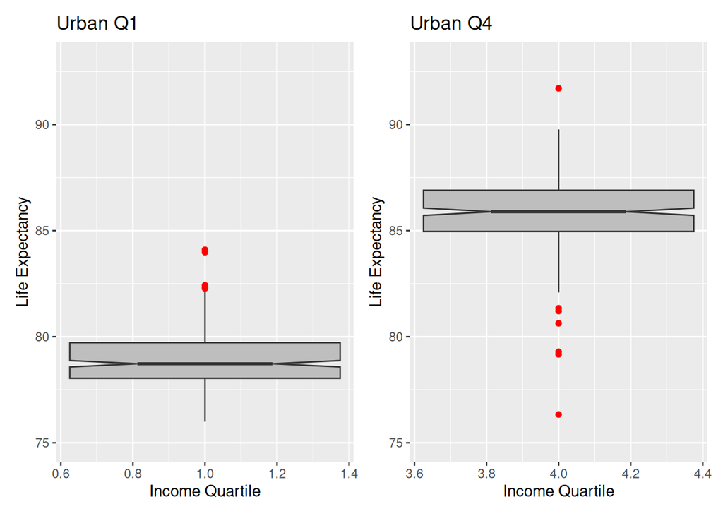

```r
is_urban1 + is_urban4
```

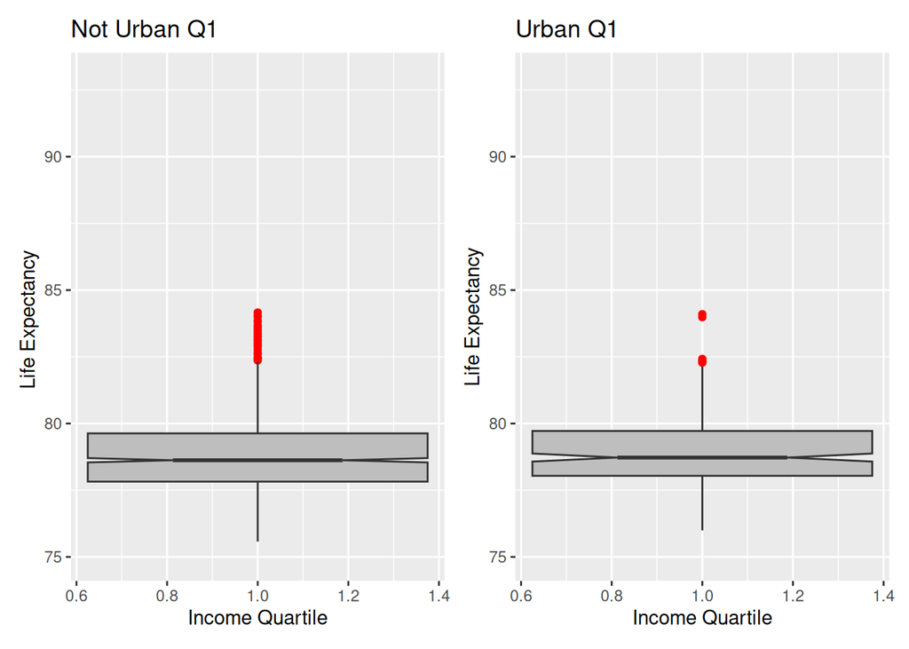

```r
not_urban1 + is_urban1
```

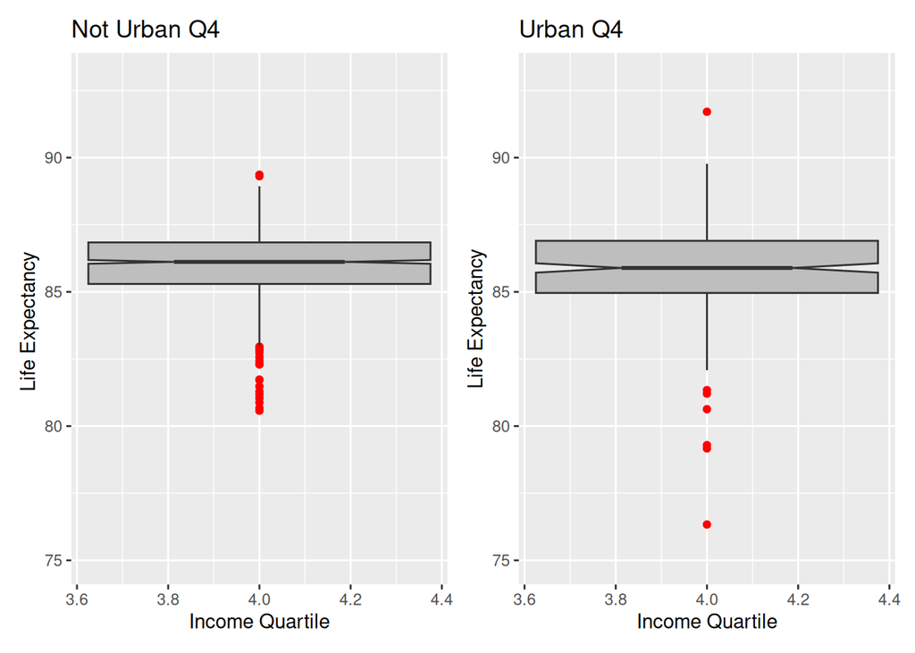

```r
not_urban4 + is_urban4
```

### [6]

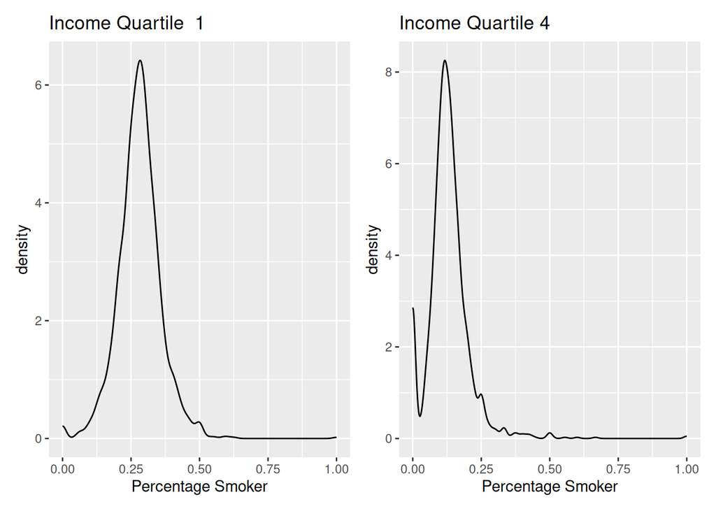

```r
create_density = function(df, x, title, x_axis)  {
  ggplot(data = df,
                 aes(x = {{x}}))+
  geom_density()+
    labs(title = title, x = x_axis) }

filtered_q1 = filter(life_df, high_income == 0)
filtered_q4 = filter(life_df, high_income == 1)


smoker_q1 = create_density(filtered_q1, pct_smoke, "Income Quartile  1", "Percentage Smoker")

smoker_q4 = create_density(filtered_q4, pct_smoke, "Income Quartile 4", "Percentage Smoker")

smoker_q1 + smoker_q4
```

### [7]

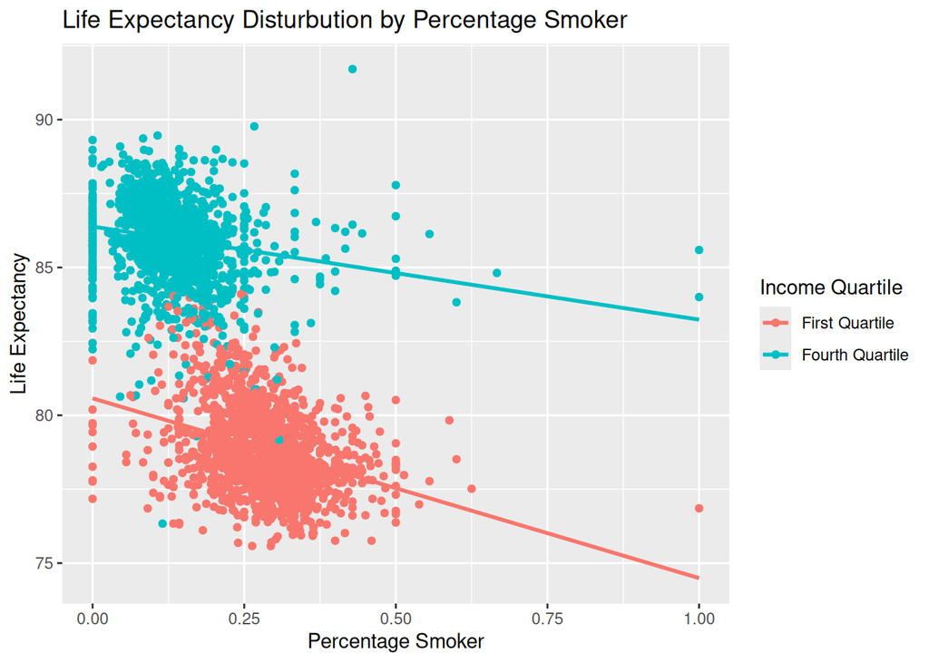

```r
ggplot(data= life_df, aes(x = pct_smoke,
                                      y = life_exp,
                                      color = factor(
                                      income_quartile,
                                      labels = c("First Quartile", "Fourth Quartile")))) +  geom_point()+
  labs(title = "Life Expectancy Disturbution by Percentage Smoker",
    x = "Percentage Smoker",
    y = "Life Expectancy",
    color = "Income Quartile") + geom_smooth(method = 'lm', se = FALSE)
```

### [8]

Figure [6] shows the density spread of smokers and non smokers in Q1 and Q4 income quartiles. We see that there is a peak in quartile 1 income where ~27% is the most frequent percentage of smokers, compared to quartile 4 income earners where the highest frequency of percentage smokers in the population is at ~12.5%. The model tells us that the most frequent distribution of smokers sits at ~27% for Q1 earners and the most frequent smoker distribution for Q4 is at ~12.5%.

Figure [7] shows a scatterplot of life expectancy and percentage of smokers between Q1 and Q4 income earners. It shows a negative correlation between smoker percentage and life expectancy, however the Q1 income earners have a steeper slope than Q4. This tells us that per percentage increase in smoking population and Q1 earners, life expectancy will decrease more than compared to a percentage increase in smoking population among Q4 earners.

From figures [5][6][7], we see that life expectancy is generally higher among Q4 earners, they are less likely to be smoking, and per increase in percentage of the smoker population, the life expectancy is still projected to live longer than those in Q1. Generally there was not much of a difference in urban vs non urban in terms of averages, and we see that urban vs non urban in both groups generally have the same spread of life expectancy.

### [9]

The scatter plot shows the distinction betwee zsA n Q1 and Q4 income earners. If we regressed on only smoking rate and life expectancy, the line would go through the two clouds and there would be a high variance. Omitted variable bias would occur because there is a visual distinction between the two life expectancy of Q1 and Q4in terms of life expectancy.

### [10]

Omitting the income variable would still result in a negative b1 coefficient when predicting life expectancy. In figure [7], we see that both plots have a negative downward trend, omitting the offset of income would result in a regression between thE two clouds, which would still be a downtrend. This is accurate from the variable we are regressing on as smoking does not increase life expectancy.

```r
smoke_reg = lm(life_exp ~ pct_smoke, data = life_df)
smoke_income = lm(life_exp ~ pct_smoke + high_income, data = life_df)

smoke_reg
```

```
##
## Call:
## lm(formula = life_exp ~ pct_smoke, data = life_df)
##
## Coefficients:
## (Intercept)    pct_smoke
##       87.51       -24.81
```

```r
smoke_income
```

```
##
## Call:
## lm(formula = life_exp ~ pct_smoke + high_income, data = life_df)
##
## Coefficients:
## (Intercept)    pct_smoke  high_income
##      80.164       -4.623        6.411
```

### [11]

```r
summary = tibble(
  id = c("Smoking", "Smoking + Income"),
  intercept = c(87.51, 80.164),
  pct_smoke = c(-24.81 , -4.6230),
  high_income = c(0, 6.411))
summary
```

```
## # A tibble: 2 × 4
##   id               intercept pct_smoke high_income
##   <chr>                <dbl>     <dbl>       <dbl>
## 1 Smoking               87.5    -24.8         0
## 2 Smoking + Income      80.2     -4.62        6.41
```

### [12]

The result in table [11] is consistent with my prediction [10]. We see that without including income quartile as a predictor, the intercept is 87 years (when the smoking population is 0), with a decrease of 2.48 years for every 10 percentage point increase. Regressing smoking on income, having a high income conditional increases life expectancy to 86.5 years (intercept) and on a 10 percentage point basis, for every 10% increase in smoking percentage, we see that life expectancy will decrease by 0.46 years. Those who are in income quartile 1 will have a life expectnacy of 80.16 years when smoking population is 0

### [13]

Adding the urban indicator did not change anything meaningful to the life expectancy predictor. This tells us that not all omitted variables will have a significant contribution to the predictor outcome.

```r
smoke_income_u = lm(life_exp ~ pct_smoke + high_income + is_urban, data = life_df)

smoke_income_u
```

```
##
## Call:
## lm(formula = life_exp ~ pct_smoke + high_income + is_urban, data = life_df)
##
## Coefficients:
## (Intercept)    pct_smoke  high_income     is_urban
##    80.12132     -4.62364      6.41054      0.05368
```

```r
summary = tibble(
  id = c("Smoking + Income + Urban"),
  intercept = c(80.12132),
  pct_smoke = c(-4.62364),
  high_income = c(6.41054),
  is_urban = c(0.05368))
summary
```

```
## # A tibble: 1 × 5
##   id                       intercept pct_smoke high_income is_urban
##   <chr>                        <dbl>     <dbl>       <dbl>    <dbl>
## 1 Smoking + Income + Urban      80.1     -4.62        6.41   0.0537
```

### [14]

The plots do suggest heteroskedasticity, there is a cloud that stretches to the side as smoking rate increases. It could be argued that it can be considered homoscedastic.

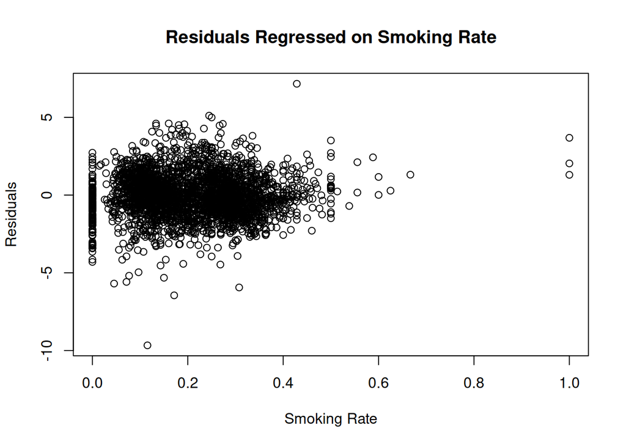

```r
life_df$e = residuals(smoke_income_u)
plot(life_df$pct_smoke, life_df$e, main = "Residuals Regressed on Smoking Rate", xlab = "Smoking Rate", ylab = "Residuals")
```

### [15]

The OLS coefficients estimates would not be able to accurately describe all the data in the presence of heteroskedasticity. This in turn would mean there would be a greater OLS standard or a larger uncertainty in predicting with the model. Larger deviation from the OLS estimation would result in a larger variance in the data.

### [16]

The P value is 0.99 > 0.05. We conclude that the model shows no statistically significant evidence against the null hypothesis. Therefore we fail to reject the null H0.

```r
smoke_df = arrange(life_df, pct_smoke)
third = floor(nrow(life_df)/3)
estmodel1 = lm(life_exp ~ pct_smoke + high_income + is_urban, data = tail(smoke_df, third))
estmodel2 = lm(life_exp ~ pct_smoke + high_income + is_urban, data = head(smoke_df, third))

res_model1 = resid(estmodel1)
res_model2 = resid(estmodel2)

sse_model1 = sum(res_model1^2)
sse_model2 = sum(res_model2^2)

f_gq = sse_model1/sse_model2

pf(q = f_gq, df1 = third - 4, df2 = third - 4, lower.tail = F)
```

```
## [1] 0.9904181
```

### [17]

```r
white_model = lm(
  I(e^2) ~ pct_smoke + high_income + is_urban + I(pct_smoke^2) + pct_smoke:high_income + pct_smoke:is_urban + high_income:is_urban, data = life_df)
# White test R squared
white_r2 = summary(white_model)$r.squared
# White test statistic
white_stat = white_r2 * length(life_df$e)
# Calculate P value
pchisq(q = white_stat, df = 7, lower.tail = F)
```

```
## [1] 2.039414e-24
```

### [18]

The Goldfeld-Quandt test and White test did not agree in this instance. We see that the White test produced a result of 0.0 < 0.05 which says that it is statistically significant that the relationship is not due to chance, ie we reject the null hypothesis and it is heteroskedastic. In this application we regressed on the variables as well as its interaction terms. The White tests regresses the residuals squared on the variables and its interaction to see if there are interactions. The Goldfeld - Quandt test is good when there is large heteroskedasticity among the first and third portion (linearly checking) but White Tests looks for any non linear interactions.

### [19]

The predicted life expectancy when all over factors are 0 is 80.5 years old. For each 10% unit increase of percentage smokers, the life expectancy does down by 0.6 years. If the group is high income, life expectancy goes up by 5.8, and for those who are high income and smokers, life expectancy is offset by 2.9 years. Urbanism adds 0.03 years to the life expectancy (not much there).

```r
life_expectancy = lm(life_exp ~ pct_smoke + high_income + is_urban + pct_smoke:high_income, data = life_df)

summary(life_expectancy)
```

```
##
## Call:
## lm(formula = life_exp ~ pct_smoke + high_income + is_urban +
##     pct_smoke:high_income, data = life_df)
##
## Residuals:
##     Min      1Q  Median      3Q     Max
## -9.6589 -0.8503 -0.0139  0.8373  6.7040
##
## Coefficients:
##                       Estimate Std. Error t value Pr(>|t|)
## (Intercept)           80.54369    0.13772 584.830  < 2e-16 ***
## pct_smoke             -6.06857    0.43350 -13.999  < 2e-16 ***
## high_income            5.81515    0.14288  40.700  < 2e-16 ***
## is_urban               0.03257    0.06101   0.534    0.593
## pct_smoke:high_income  2.90776    0.61579   4.722 2.44e-06 ***
## ---
## Signif. codes:  0 '***' 0.001 '**' 0.01 '*' 0.05 '.' 0.1 ' ' 1
##
## Residual standard error: 1.357 on 3101 degrees of freedom
## Multiple R-squared:  0.8742, Adjusted R-squared:  0.8741
## F-statistic:  5388 on 4 and 3101 DF,  p-value: < 2.2e-16
```

### [20]

Per 10% increase in smoking, those in the low income would see a decrease in life expectancy by -0.60 years whereas those who are in the high income would see a decrease in life expectancy by -0.31 years.

```r
low_income =  -6.06857 * 0.1
high_income =(-6.06857 + 2.90776) * 0.1

low_income
```

```
## [1] -0.606857
```

```r
high_income
```

```
## [1] -0.316081
```

### [21]

```r
p_load(fixest)
life_reg = feols(life_exp ~ pct_smoke + high_income + is_urban + pct_smoke:high_income, data = life_df,vcov = 'hetero')

model_21 = summary(life_reg)
model_19 = summary(life_expectancy)
model_19
```

```
##
## Call:
## lm(formula = life_exp ~ pct_smoke + high_income + is_urban +
##     pct_smoke:high_income, data = life_df)
##
## Residuals:
##     Min      1Q  Median      3Q     Max
## -9.6589 -0.8503 -0.0139  0.8373  6.7040
##
## Coefficients:
##                       Estimate Std. Error t value Pr(>|t|)
## (Intercept)           80.54369    0.13772 584.830  < 2e-16 ***
## pct_smoke             -6.06857    0.43350 -13.999  < 2e-16 ***
## high_income            5.81515    0.14288  40.700  < 2e-16 ***
## is_urban               0.03257    0.06101   0.534    0.593
## pct_smoke:high_income  2.90776    0.61579   4.722 2.44e-06 ***
## ---
## Signif. codes:  0 '***' 0.001 '**' 0.01 '*' 0.05 '.' 0.1 ' ' 1
##
## Residual standard error: 1.357 on 3101 degrees of freedom
## Multiple R-squared:  0.8742, Adjusted R-squared:  0.8741
## F-statistic:  5388 on 4 and 3101 DF,  p-value: < 2.2e-16
```

```r
model_21
```

```
## OLS estimation, Dep. Var.: life_exp
## Observations: 3,106
## Standard-errors: Heteroskedasticity-robust
##                        Estimate Std. Error    t value   Pr(>|t|)
## (Intercept)           80.543689   0.168386 478.326386  < 2.2e-16 ***
## pct_smoke             -6.068569   0.513658 -11.814411  < 2.2e-16 ***
## high_income            5.815147   0.174733  33.280255  < 2.2e-16 ***
## is_urban               0.032568   0.067935   0.479393 0.63169255
## pct_smoke:high_income  2.907757   0.749352   3.880360 0.00010647 ***
## ---
## Signif. codes:  0 '***' 0.001 '**' 0.01 '*' 0.05 '.' 0.1 ' ' 1
## RMSE: 1.35591   Adj. R2: 0.874058
```

### [22]

All of the variables have a p value of less than 0 which is statistically significant, to which we can reject the null hypothesis.

Weighted estimates does not automatically solve for heteroskedasticity. For WLS to work efficiently, the weights needs to be accurate and the original model’s equation also needs to be accurate to model the correct prediction. In this model, weighting the regression on population allowed for a more accurate regression model, but it is not always the case if the wrong weight is chosen.

```r
w_life_reg = feols(life_exp ~ pct_smoke + high_income + is_urban + pct_smoke:high_income, data = life_df,weights = ~pop, vcov = 'hetero')

model_19 = summary(life_expectancy)
model_22 = w_life_reg
model_19
```

```
##
## Call:
## lm(formula = life_exp ~ pct_smoke + high_income + is_urban +
##     pct_smoke:high_income, data = life_df)
##
## Residuals:
##     Min      1Q  Median      3Q     Max
## -9.6589 -0.8503 -0.0139  0.8373  6.7040
##
## Coefficients:
##                       Estimate Std. Error t value Pr(>|t|)
## (Intercept)           80.54369    0.13772 584.830  < 2e-16 ***
## pct_smoke             -6.06857    0.43350 -13.999  < 2e-16 ***
## high_income            5.81515    0.14288  40.700  < 2e-16 ***
## is_urban               0.03257    0.06101   0.534    0.593
## pct_smoke:high_income  2.90776    0.61579   4.722 2.44e-06 ***
## ---
## Signif. codes:  0 '***' 0.001 '**' 0.01 '*' 0.05 '.' 0.1 ' ' 1
##
## Residual standard error: 1.357 on 3101 degrees of freedom
## Multiple R-squared:  0.8742, Adjusted R-squared:  0.8741
## F-statistic:  5388 on 4 and 3101 DF,  p-value: < 2.2e-16
```

```r
model_22
```

```
## OLS estimation, Dep. Var.: life_exp
## Observations: 3,106
## Weights: pop
## Standard-errors: Heteroskedasticity-robust
##                         Estimate Std. Error   t value   Pr(>|t|)
## (Intercept)            84.786246   0.608756 139.27786  < 2.2e-16 ***
## pct_smoke             -20.699278   2.046186 -10.11603  < 2.2e-16 ***
## high_income             2.142230   0.625624   3.42415 6.2474e-04 ***
## is_urban                0.278364   0.082611   3.36958 7.6204e-04 ***
## pct_smoke:high_income  13.399508   2.165068   6.18896 6.8518e-10 ***
## ---
## Signif. codes:  0 '***' 0.001 '**' 0.01 '*' 0.05 '.' 0.1 ' ' 1
## RMSE: 1.2303   Adj. R2: 0.88643
```

### [23]

Correlated disturbances happen when disturbances overlap with variables that are not modeled in the regression or the sample may relate to other observations. There is overlap in the data that is not accurately being represented. This becomes a problem because this causes overconfidence in th prediction of the model under the assumption that the observations are independent. This can lead us to false positives or incorrect conclusions.

### [24] Update the regression from [19] to use cluster-robust standard errors, clustering at the county level (county_code). Show the results.

```r
county_cluster = feols(life_exp ~ pct_smoke + high_income + is_urban + pct_smoke:high_income, data = life_df, cluster = "county_code")

model_24 = county_cluster
model_24
```

```
## OLS estimation, Dep. Var.: life_exp
## Observations: 3,106
## Standard-errors: Clustered (county_code)
##                        Estimate Std. Error    t value   Pr(>|t|)
## (Intercept)           80.543689   0.169784 474.389589  < 2.2e-16 ***
## pct_smoke             -6.068569   0.513184 -11.825339  < 2.2e-16 ***
## high_income            5.815147   0.164975  35.248553  < 2.2e-16 ***
## is_urban               0.032568   0.076261   0.427054 6.6940e-01
## pct_smoke:high_income  2.907757   0.712721   4.079798 4.7362e-05 ***
## ---
## Signif. codes:  0 '***' 0.001 '**' 0.01 '*' 0.05 '.' 0.1 ' ' 1
## RMSE: 1.35591   Adj. R2: 0.874058
```

### [25]

```r
model_21
```

```
## OLS estimation, Dep. Var.: life_exp
## Observations: 3,106
## Standard-errors: Heteroskedasticity-robust
##                        Estimate Std. Error    t value   Pr(>|t|)
## (Intercept)           80.543689   0.168386 478.326386  < 2.2e-16 ***
## pct_smoke             -6.068569   0.513658 -11.814411  < 2.2e-16 ***
## high_income            5.815147   0.174733  33.280255  < 2.2e-16 ***
## is_urban               0.032568   0.067935   0.479393 0.63169255
## pct_smoke:high_income  2.907757   0.749352   3.880360 0.00010647 ***
## ---
## Signif. codes:  0 '***' 0.001 '**' 0.01 '*' 0.05 '.' 0.1 ' ' 1
## RMSE: 1.35591   Adj. R2: 0.874058
```

```r
model_24
```

```
## OLS estimation, Dep. Var.: life_exp
## Observations: 3,106
## Standard-errors: Clustered (county_code)
##                        Estimate Std. Error    t value   Pr(>|t|)
## (Intercept)           80.543689   0.169784 474.389589  < 2.2e-16 ***
## pct_smoke             -6.068569   0.513184 -11.825339  < 2.2e-16 ***
## high_income            5.815147   0.164975  35.248553  < 2.2e-16 ***
## is_urban               0.032568   0.076261   0.427054 6.6940e-01
## pct_smoke:high_income  2.907757   0.712721   4.079798 4.7362e-05 ***
## ---
## Signif. codes:  0 '***' 0.001 '**' 0.01 '*' 0.05 '.' 0.1 ' ' 1
## RMSE: 1.35591   Adj. R2: 0.874058
```

### [26]

```r
state_cluster = feols(life_exp ~ pct_smoke + high_income + is_urban + pct_smoke:high_income, data = life_df, cluster = "state_abb")

model_26 = summary(state_cluster)

model_24
```

```
## OLS estimation, Dep. Var.: life_exp
## Observations: 3,106
## Standard-errors: Clustered (county_code)
##                        Estimate Std. Error    t value   Pr(>|t|)
## (Intercept)           80.543689   0.169784 474.389589  < 2.2e-16 ***
## pct_smoke             -6.068569   0.513184 -11.825339  < 2.2e-16 ***
## high_income            5.815147   0.164975  35.248553  < 2.2e-16 ***
## is_urban               0.032568   0.076261   0.427054 6.6940e-01
## pct_smoke:high_income  2.907757   0.712721   4.079798 4.7362e-05 ***
## ---
## Signif. codes:  0 '***' 0.001 '**' 0.01 '*' 0.05 '.' 0.1 ' ' 1
## RMSE: 1.35591   Adj. R2: 0.874058
```

```r
model_26
```

```
## OLS estimation, Dep. Var.: life_exp
## Observations: 3,106
## Standard-errors: Clustered (state_abb)
##                        Estimate Std. Error    t value   Pr(>|t|)
## (Intercept)           80.543689   0.398631 202.050883  < 2.2e-16 ***
## pct_smoke             -6.068569   1.108392  -5.475112 1.4896e-06 ***
## high_income            5.815147   0.386299  15.053494  < 2.2e-16 ***
## is_urban               0.032568   0.107188   0.303837 7.6254e-01
## pct_smoke:high_income  2.907757   1.278428   2.274478 2.7352e-02 *
## ---
## Signif. codes:  0 '***' 0.001 '**' 0.01 '*' 0.05 '.' 0.1 ' ' 1
## RMSE: 1.35591   Adj. R2: 0.874058
```

### [27]

```r
model_19
```

```
##
## Call:
## lm(formula = life_exp ~ pct_smoke + high_income + is_urban +
##     pct_smoke:high_income, data = life_df)
##
## Residuals:
##     Min      1Q  Median      3Q     Max
## -9.6589 -0.8503 -0.0139  0.8373  6.7040
##
## Coefficients:
##                       Estimate Std. Error t value Pr(>|t|)
## (Intercept)           80.54369    0.13772 584.830  < 2e-16 ***
## pct_smoke             -6.06857    0.43350 -13.999  < 2e-16 ***
## high_income            5.81515    0.14288  40.700  < 2e-16 ***
## is_urban               0.03257    0.06101   0.534    0.593
## pct_smoke:high_income  2.90776    0.61579   4.722 2.44e-06 ***
## ---
## Signif. codes:  0 '***' 0.001 '**' 0.01 '*' 0.05 '.' 0.1 ' ' 1
##
## Residual standard error: 1.357 on 3101 degrees of freedom
## Multiple R-squared:  0.8742, Adjusted R-squared:  0.8741
## F-statistic:  5388 on 4 and 3101 DF,  p-value: < 2.2e-16
```

```r
model_21 # hetero robust
```

```
## OLS estimation, Dep. Var.: life_exp
## Observations: 3,106
## Standard-errors: Heteroskedasticity-robust
##                        Estimate Std. Error    t value   Pr(>|t|)
## (Intercept)           80.543689   0.168386 478.326386  < 2.2e-16 ***
## pct_smoke             -6.068569   0.513658 -11.814411  < 2.2e-16 ***
## high_income            5.815147   0.174733  33.280255  < 2.2e-16 ***
## is_urban               0.032568   0.067935   0.479393 0.63169255
## pct_smoke:high_income  2.907757   0.749352   3.880360 0.00010647 ***
## ---
## Signif. codes:  0 '***' 0.001 '**' 0.01 '*' 0.05 '.' 0.1 ' ' 1
## RMSE: 1.35591   Adj. R2: 0.874058
```

```r
model_22 # weighted pop
```

```
## OLS estimation, Dep. Var.: life_exp
## Observations: 3,106
## Weights: pop
## Standard-errors: Heteroskedasticity-robust
##                         Estimate Std. Error   t value   Pr(>|t|)
## (Intercept)            84.786246   0.608756 139.27786  < 2.2e-16 ***
## pct_smoke             -20.699278   2.046186 -10.11603  < 2.2e-16 ***
## high_income             2.142230   0.625624   3.42415 6.2474e-04 ***
## is_urban                0.278364   0.082611   3.36958 7.6204e-04 ***
## pct_smoke:high_income  13.399508   2.165068   6.18896 6.8518e-10 ***
## ---
## Signif. codes:  0 '***' 0.001 '**' 0.01 '*' 0.05 '.' 0.1 ' ' 1
## RMSE: 1.2303   Adj. R2: 0.88643
```

```r
model_24 # county cluster
```

```
## OLS estimation, Dep. Var.: life_exp
## Observations: 3,106
## Standard-errors: Clustered (county_code)
##                        Estimate Std. Error    t value   Pr(>|t|)
## (Intercept)           80.543689   0.169784 474.389589  < 2.2e-16 ***
## pct_smoke             -6.068569   0.513184 -11.825339  < 2.2e-16 ***
## high_income            5.815147   0.164975  35.248553  < 2.2e-16 ***
## is_urban               0.032568   0.076261   0.427054 6.6940e-01
## pct_smoke:high_income  2.907757   0.712721   4.079798 4.7362e-05 ***
## ---
## Signif. codes:  0 '***' 0.001 '**' 0.01 '*' 0.05 '.' 0.1 ' ' 1
## RMSE: 1.35591   Adj. R2: 0.874058
```

```r
model_26  # state cluster
```

```
## OLS estimation, Dep. Var.: life_exp
## Observations: 3,106
## Standard-errors: Clustered (state_abb)
##                        Estimate Std. Error    t value   Pr(>|t|)
## (Intercept)           80.543689   0.398631 202.050883  < 2.2e-16 ***
## pct_smoke             -6.068569   1.108392  -5.475112 1.4896e-06 ***
## high_income            5.815147   0.386299  15.053494  < 2.2e-16 ***
## is_urban               0.032568   0.107188   0.303837 7.6254e-01
## pct_smoke:high_income  2.907757   1.278428   2.274478 2.7352e-02 *
## ---
## Signif. codes:  0 '***' 0.001 '**' 0.01 '*' 0.05 '.' 0.1 ' ' 1
## RMSE: 1.35591   Adj. R2: 0.874058
```